# Assignment 2 - Transit-Oriented Development

Zile Wu

2022-09-16

# Task 1.Intro: Show Your Data Wrangling Work.

- This rmd document will present information about TOD in Chicago, the capital city of Illinois, based on 2009 and 2017 ACS 5-year estimates data. and illustrate the following issues:

- Do households value transit-rich neighborhoods compared to others?

# Task 2.Four Small-Multiple Visualizations Comparing Four Selected Census Variables Across Time and Space (TOD vs. non-TOD).

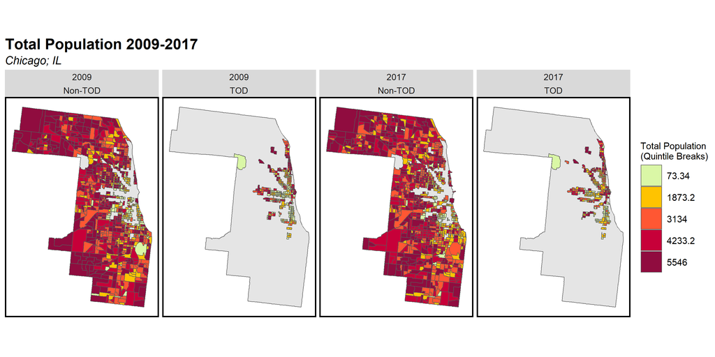

```r
ggplot() +
  geom_sf(data=st_union(tracts2009)) +
  geom_sf(data = allTracts.group, aes(fill = q6(TotalPop))) +
  scale_fill_manual(values = palette4,
                    labels = qBr2(allTracts.group, "TotalPop"),
                    name = "Total Population\n(Quintile Breaks)") +
  labs(title = "Total Population 2009-2017", subtitle = "Chicago; IL") +
  facet_wrap(c(~year,~TOD), ncol=4)+
  mapTheme() + theme(plot.title = element_text(size=24,face="bold"),legend.key.height = unit(35, "pt"),
   legend.key.width = unit(35, "pt"),legend.title = element_text(size = 15),legend.text = element_text(size = 15),plot.subtitle = element_text(size=18))
```

## Mapping 1.Total Population.

From the set of graphs above, we can see that as time increases,

1. the population in the TOD area, especially in the central area, increases.

2. The population in Non-TOD area, there is a rise in the population in tracts close to the TOD area (e.g. along the southeast part of the river); there is a decrease in the population in tracts far from the TOD area (e.g. northwest & southwest parts).

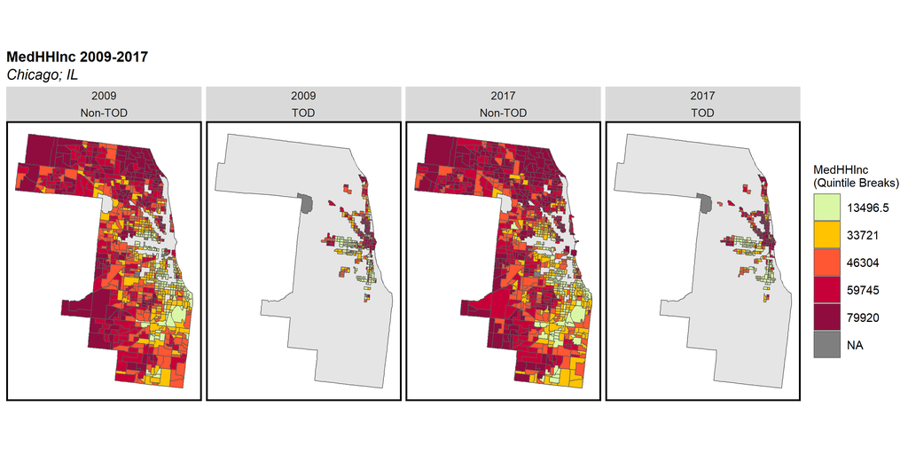

```r
ggplot() +
  geom_sf(data=st_union(tracts2009)) +
  geom_sf(data = allTracts.group, aes(fill = q6(MedHHInc))) +
  scale_fill_manual(values = palette4,
                    labels = qBr2(allTracts.group, "MedHHInc"),
                    name = "MedHHInc\n(Quintile Breaks)") +
  labs(title = "MedHHInc 2009-2017", subtitle = "Chicago; IL") +
  facet_wrap(c(~year,~TOD), ncol=4)+
  mapTheme() + theme(plot.title = element_text(size=18,face="bold"),legend.key.height = unit(35, "pt"),
   legend.key.width = unit(35, "pt"),legend.title = element_text(size = 15),legend.text = element_text(size = 15),plot.subtitle = element_text(size=18))
```

## Mapping 2. Medium House Income.

Here more gray data appears in the map data. Information on median household income is left for subsequent analysis.

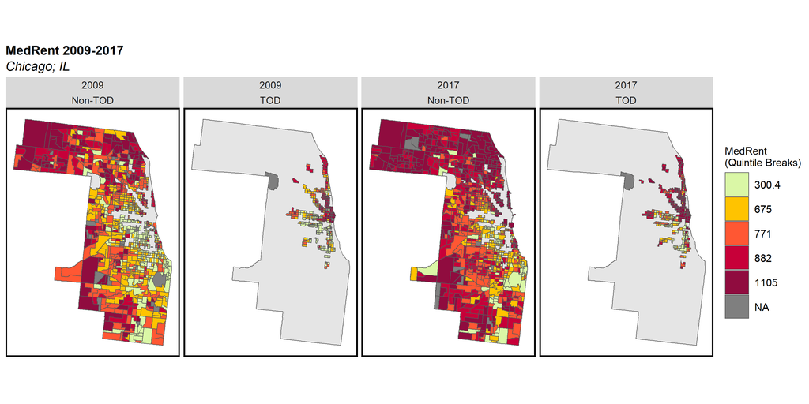

```r
ggplot() +
  geom_sf(data=st_union(tracts2009)) +
  geom_sf(data = allTracts.group, aes(fill = q6(MedRent))) +
  scale_fill_manual(values = palette4,
                    labels = qBr2(allTracts.group, "MedRent"),
                    name = "MedRent\n(Quintile Breaks)") +
  labs(title = "MedRent 2009-2017", subtitle = "Chicago; IL") +
  facet_wrap(c(~year,~TOD), ncol=4)+
  mapTheme() + theme(plot.title = element_text(size=18,face="bold"),legend.key.height = unit(35, "pt"),
   legend.key.width = unit(35, "pt"),legend.title = element_text(size = 15),legend.text = element_text(size = 15),plot.subtitle = element_text(size=18))
```

## Mapping 3. Medium Rent.

Here more gray data appears in the map data. Information on median rent is left for subsequent analysis.

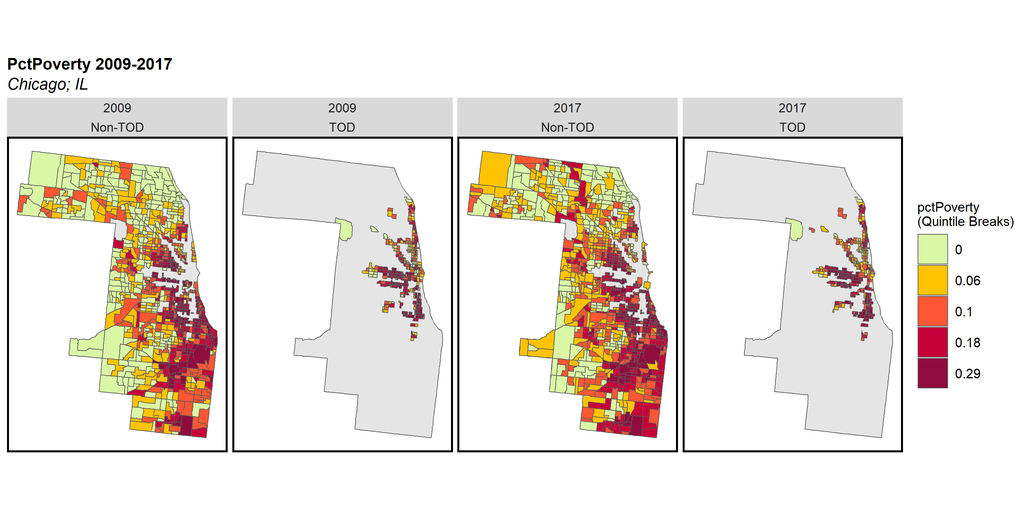

```r
ggplot() +
  geom_sf(data=st_union(tracts2009)) +
  geom_sf(data = allTracts.group, aes(fill = q6(pctPoverty))) +
  scale_fill_manual(values = palette4,
                    labels = qBr2(allTracts.group, "pctPoverty"),
                    name = "pctPoverty\n(Quintile Breaks)") +
  labs(title = "PctPoverty 2009-2017", subtitle = "Chicago; IL") +
  facet_wrap(c(~year,~TOD), ncol=4)+
  mapTheme() + theme(plot.title = element_text(size=18,face="bold"),legend.key.height = unit(35, "pt"),
   legend.key.width = unit(35, "pt"),legend.title = element_text(size = 15),legend.text = element_text(size = 15),plot.subtitle = element_text(size=18))
```

## Mapping 4. Percentage Poverty

Here we can see a similar situation to the population. Overall Non-TOD areas away from TOD areas have increased poverty rates

# Task 3.One Grouped Bar Plot Making These Same Comparisons.

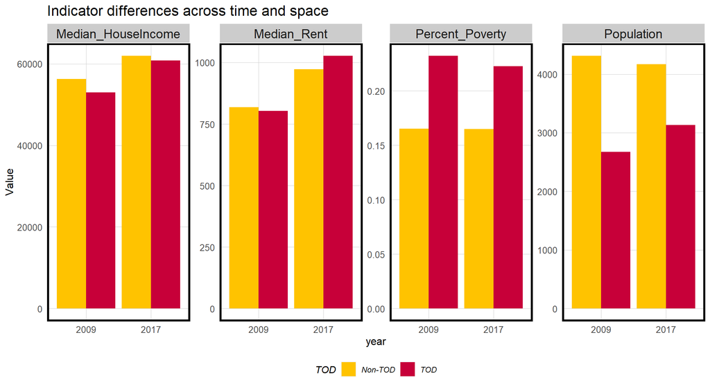

```r
allTracts.Summary %>%
  gather(Variable, Value, -year, -TOD) %>%
  ggplot(aes(year, Value, fill = TOD)) +
  geom_bar(stat = "identity", position = "dodge") +
  facet_wrap(~Variable, scales = "free", ncol=5) +
  scale_fill_manual(values = c("#FFC300", "#C70039")) +
  labs(title = "Indicator differences across time and space") +
  plotTheme() + theme(legend.position="bottom")
```

# Task 4.One Table Making These Same Comparisons.

```r
kable(allTracts.Summary) %>%
  kable_styling(bootstrap_options = c("striped", "hover", "condensed", "responsive")) %>%
  footnote(general_title = "\n")
```

| year | TOD | Population | Median_Rent | Median_HouseIncome | Percent_Poverty |
| --- | --- | --- | --- | --- | --- |
| 2009 | Non-TOD | 4314.253 | 818.4373 | 56323.51 | 0.1652232 |
| 2009 | TOD | 2673.329 | 803.7615 | 52972.85 | 0.2322659 |
| 2017 | Non-TOD | 4168.119 | 972.9492 | 61989.03 | 0.1650124 |
| 2017 | TOD | 3129.911 | 1027.6388 | 60847.14 | 0.2225269 |

As we can see from the image and table from Task3&4, the population within the TOD area does show a growing trend and the poverty rate has decreased. But with the overall economic growth from 2009 to 2017, it only shows that there is a preference for TOD areas at this point, but the economic benefits they bring are not significant.

# Task 5.Two Graduated Symbol Maps Of Population and Rent

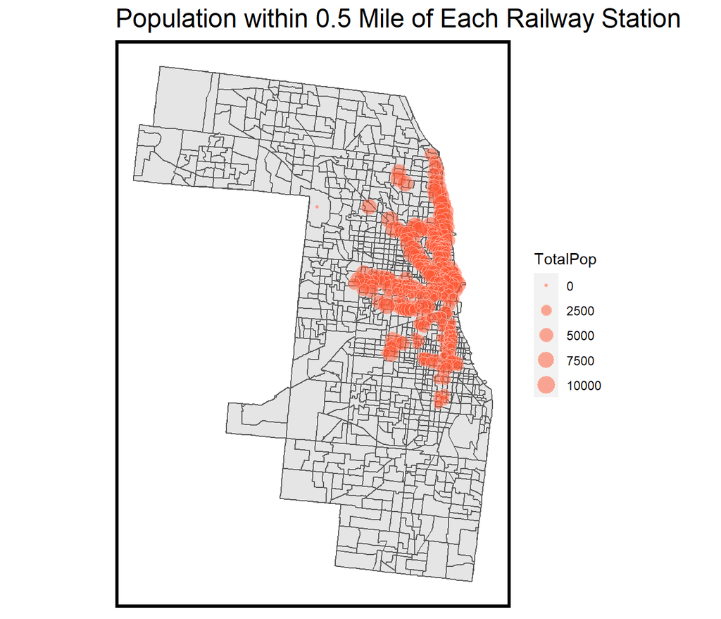

```r
ggplot() +
  geom_sf(data = st_union(allTracts),fill = "#f0f9e8") +
  geom_sf(data = buffer,fill = NA) +
  geom_sf(data = tracts2009) +
  geom_sf(
          data=st_centroid(selectCentroids),
          pch=21,
          aes(size=TotalPop),
          fill="#FF5733",
          color="transparent",
          alpha=0.5,
          show="point"
          )+
  labs(title = "Population within 0.5 Mile of Each Railway Station")+
  mapTheme()+theme(plot.title = element_text(size=18))
```

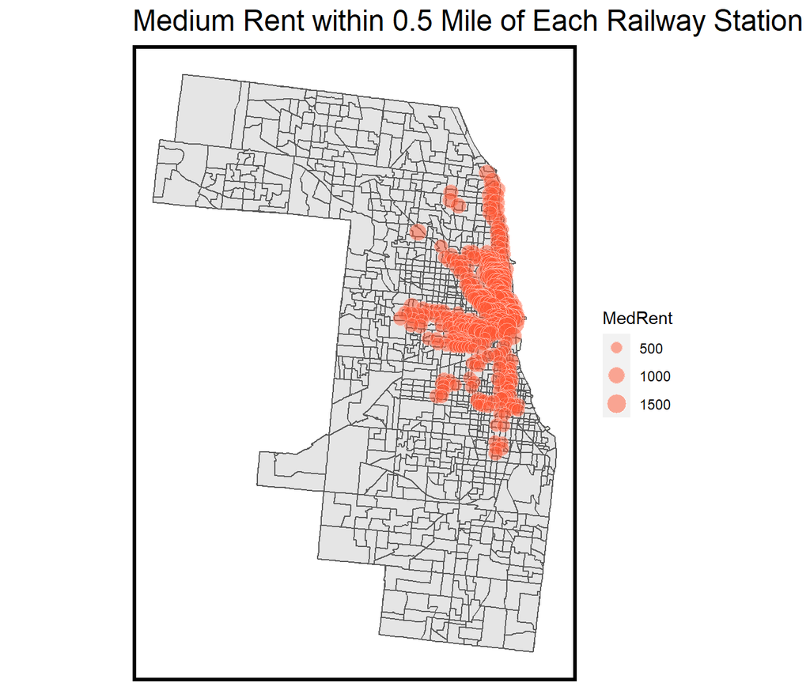

```r
ggplot() +
  geom_sf(data = st_union(allTracts),fill = "#f0f9e8") +
  geom_sf(data = buffer,fill = NA) +
  geom_sf(data = tracts2009) +
  geom_sf(
          data=st_centroid(selectCentroids),
          pch=21,
          aes(size=MedRent),
          fill="#FF5733",
          color="transparent",
          alpha=0.5,
          show="point"
          )+
  labs(title = "Medium Rent within 0.5 Mile of Each Railway Station")+
  mapTheme()+theme(plot.title = element_text(size=18))
```

As we can see from the image above, The downtown area in the eastern part of Chicago, near the lake, enjoys higher population density and area rents, seemingly demonstrating a positive correlation between population and transportation development.

# Task 6.Mean Rent as a Function of Distance to Rail stations

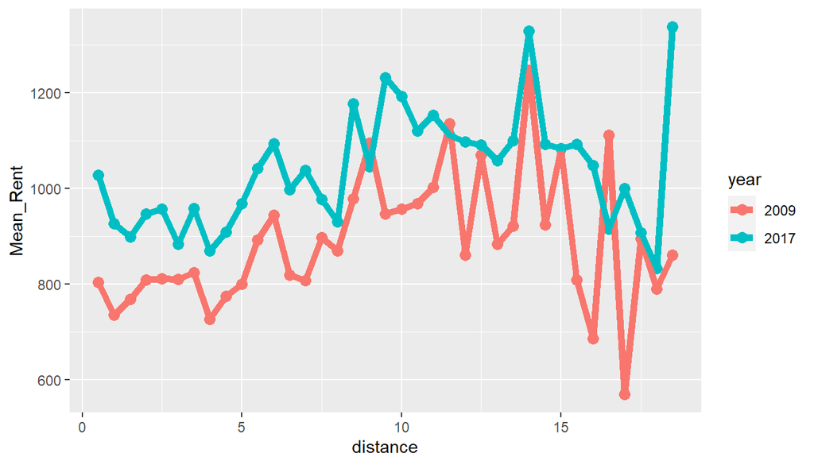

```r
allTracts.PRICE <- rbind(tracts2009.rings.summary,tracts2017.rings.summary)


ggplot(allTracts.PRICE,
       aes(distance, Mean_Rent, colour=year)) +
      geom_point(size=3) +
  geom_line(size=2)
```

# Summary

Through the above analysis, we can get the following conclusions

1.TOD areas are to some extent more attractive to the population than non-Non-TOD areas.

2.TOD areas do not generally represent higher rents and housing prices than non-Non-TOD areas, and may even present the opposite situation in some tracts.

Overall, it is not possible to make a strong case that households value transit-rich neighborhoods compared to others.